# Act Report

## Intoduction

*In this report I will share my finding after wrangling some datasets regarding a twitter account named WeRateDogs.*

*I hope you find those findings helpful.*

## Findings

```python
import pandas as pd
import numpy as np
import matplotlib.pyplot as plt
import seaborn as sns
%matplotlib inline
```

```python
df_master = pd.read_csv('twitter_archive_master.csv')
```

```python
from IPython.display import HTML

HTML('''<script>
code_show=true;
function code_toggle() {
 if (code_show){
 $('div.input').hide();
 } else {
 $('div.input').show();
 }
 code_show = !code_show
}
$( document ).ready(code_toggle);
</script>
<form action="javascript:code_toggle()"><input type="submit" value=" "></form>''')
```

### Insights and Visualizations

```python
df_master.describe()
```

|  | Unnamed: 0 | tweet_id | rating_numerator | rating_denominator | favorite_count | retweet_count | img_num | Prediction_1_conf | Prediction_2_conf | Prediction_3_conf |
| --- | --- | --- | --- | --- | --- | --- | --- | --- | --- | --- |
| count | 1976.000000 | 1.976000e+03 | 1976.000000 | 1976.0 | 1976.000000 | 1976.000000 | 1976.000000 | 1976.000000 | 1.976000e+03 | 1.976000e+03 |
| mean | 987.500000 | 7.360217e+17 | 11.698381 | 10.0 | 8921.050607 | 2769.273785 | 1.202935 | 0.593646 | 1.347591e-01 | 6.018989e-02 |
| std | 570.566385 | 6.764193e+16 | 40.851248 | 0.0 | 12248.918997 | 4682.983010 | 0.561022 | 0.272086 | 1.008010e-01 | 5.077157e-02 |
| min | 0.000000 | 6.660209e+17 | 0.000000 | 10.0 | 81.000000 | 16.000000 | 1.000000 | 0.044333 | 1.011300e-08 | 1.740170e-10 |
| 25% | 493.750000 | 6.757942e+17 | 10.000000 | 10.0 | 1956.750000 | 622.750000 | 1.000000 | 0.362063 | 5.411538e-02 | 1.605498e-02 |
| 50% | 987.500000 | 7.084132e+17 | 11.000000 | 10.0 | 4141.000000 | 1354.500000 | 1.000000 | 0.587440 | 1.181350e-01 | 4.952715e-02 |
| 75% | 1481.250000 | 7.881575e+17 | 12.000000 | 10.0 | 11339.750000 | 3224.250000 | 1.000000 | 0.844247 | 1.955617e-01 | 9.162278e-02 |
| max | 1975.000000 | 8.924206e+17 | 1776.000000 | 10.0 | 132810.000000 | 79515.000000 | 4.000000 | 1.000000 | 4.880140e-01 | 2.710420e-01 |

*The table above shows some helpful informations about the data. First, as table shows, the total is 1976 tweets with avarage of 8921 favorite and 2769 retweets. Also, it shows the avarage rating of dogs, which is approximately 11.7.*

### What is the most used platform used by WeRateDogs account?

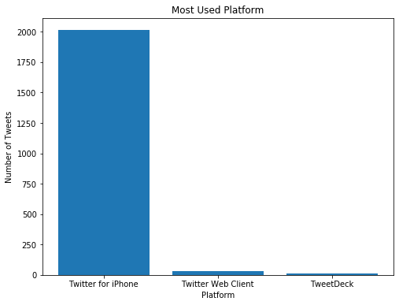

```python
source = ['Twitter for iPhone', 'Twitter Web Client', 'TweetDeck']
counts = [2014, 30, 11]

fig,ax = plt.subplots(figsize = (8,6))
ax.bar(source, counts, width = 0.8)
ax.set_ylabel('Number of Tweets')
ax.set_xlabel('Platform')
plt.title("Most Used Platform")
plt.show()
```

*We can see clearly that the iphone platform is the most dominant among the others.*

### What is The Most Popular Dog Name?

```python
df_master['name'].value_counts()
```

```
None       629
Charlie     11
Oliver      10
Cooper      10
Lucy        10
          ...
Craig        1
Ralf         1
Nugget       1
Lilli        1
Charl        1
Name: name, Length: 912, dtype: int64
```

*It appears that Charlie is the most popular dog name but not by far. Oliver, Cooper and Lucy all come in second place after Charlie.*

### What Dog Stage Get The Most Tweets?

```
(-1.2879464954626088,
 1.234046017799168,
 -1.2215265016498433,
 1.4192507289661622)
```

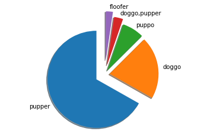

```python
counts = list(df_master[df_master['dog_stage'] != 'None']['dog_stage'].value_counts())[0:5]
stages = df_master[df_master['dog_stage'] != 'None']['dog_stage'].value_counts().index.tolist()[0:5]
explode = (0.2, 0.1, 0.1, 0.2, 0.3)

fig, ax = plt.subplots()
ax.pie(counts, explode = explode, labels = stages, shadow = True, startangle = 90)
ax.axis('equal')
```

*Dogs in Pupper stage get the most tweets*

### What Dog Breed Get The Most Tweets?

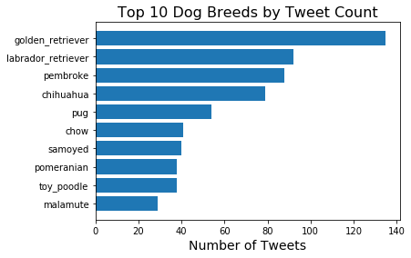

```python
counts = list(df_master[df_master['Prediction_1'] != 'none']['Prediction_1'].value_counts())[0:10]
breeds = df_master[df_master['Prediction_1'] != 'none']['Prediction_1'].value_counts().index.tolist()[0:10]


plt.barh(breeds, counts)

plt.xlabel('Number of Tweets', fontsize = 14)
# plt.ylabel('Dog Breed', fontsize = 14)
plt.title('Top 10 Dog Breeds by Tweet Count', fontsize = 16)
plt.gca().invert_yaxis()
plt.show();
```

## Conclusion

*Those findings supposed to be much harder to find without the data wrangling steps. But by following the data wrangling best practices and the use of the proper tools, the work time is decreased significantly.*